# Title of Blog Post Deliverable

## 2.3 Simulation 3 for changing maximum number of plays (L)

Assume the starting number of plays is 200, each round we would add 50 maximum plays for simulation. The maximum number of plays is 500. I used for-loop to simulate each round of different number of plays which increments 50 per round.

```r
# Assume the starting number of plays is 200, each round we would add 50 maximum plays for simulation. Below are the definition and variables needed for the simulation.

maxL = 500
number_plays = seq(200,maxL,50)
walk_out_money_final <- rep(NA, length(number_plays))
walk_out_money <- rep(NA, 10000)

# Simulation for changing winning budget threshold. I used for-loop to simulate each round of different number of plays which increments $50 per round.

for(incrementB in seq_along(walk_out_money_final)){

  for(j in seq_along(walk_out_money)){
    walk_out_money[j] <- one_series(B = 200, W = 300, L = number_plays[incrementB], M = 100) %>% get_last
  }
  walk_out_money_final[incrementB] = mean(walk_out_money - 200)
}
```

Here is the line graph indicating the relationship between maximum number of play for successfully stopping and the final walk out money balance

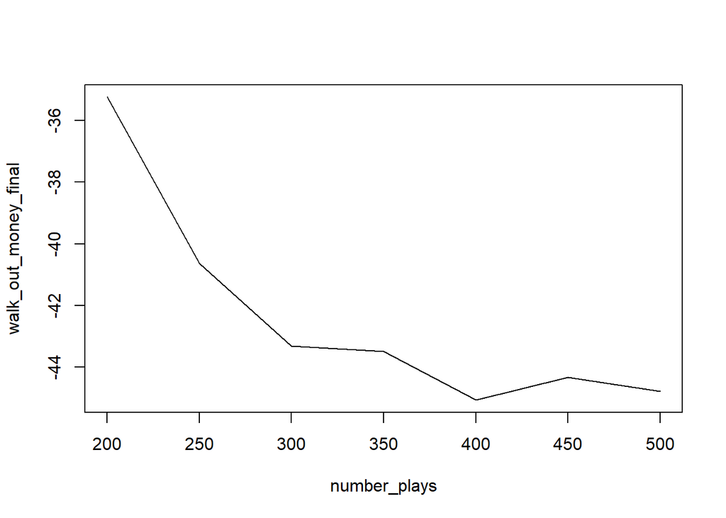

```r
plot(number_plays,walk_out_money_final,type='l')
```

From the simulation, we can know that the as the maximum number of plays increases, the player is more likely to lose.

## 2.4 Simulation 4 for changing Casino Wager Limit(M)

```r
# Assume the starting casino wager limit is $300, each round we would add $50 for simulation. The maximum casino wager limit is $300. Below are the definition and variables needed for the simulation.

maxM = 300
casino_wager_limit = seq(100,maxM,50)
walk_out_money_final <- rep(NA, length(casino_wager_limit))
walk_out_money <- rep(NA, 10000)

# Simulation for changing casino wager limit. I used for-loop to simulate each round of different wager number which increments 100 per round.

for(incrementB in seq_along(walk_out_money_final)){

  for(j in seq_along(walk_out_money)){
    walk_out_money[j] <- one_series(B = 200, W = 300, L =1000, M = casino_wager_limit[incrementB]) %>% get_last
  }
  walk_out_money_final[incrementB] = mean(walk_out_money - 200)
}
```

Here is the linegraph indicating the relationship between casino wager limit and the final walk out money balance

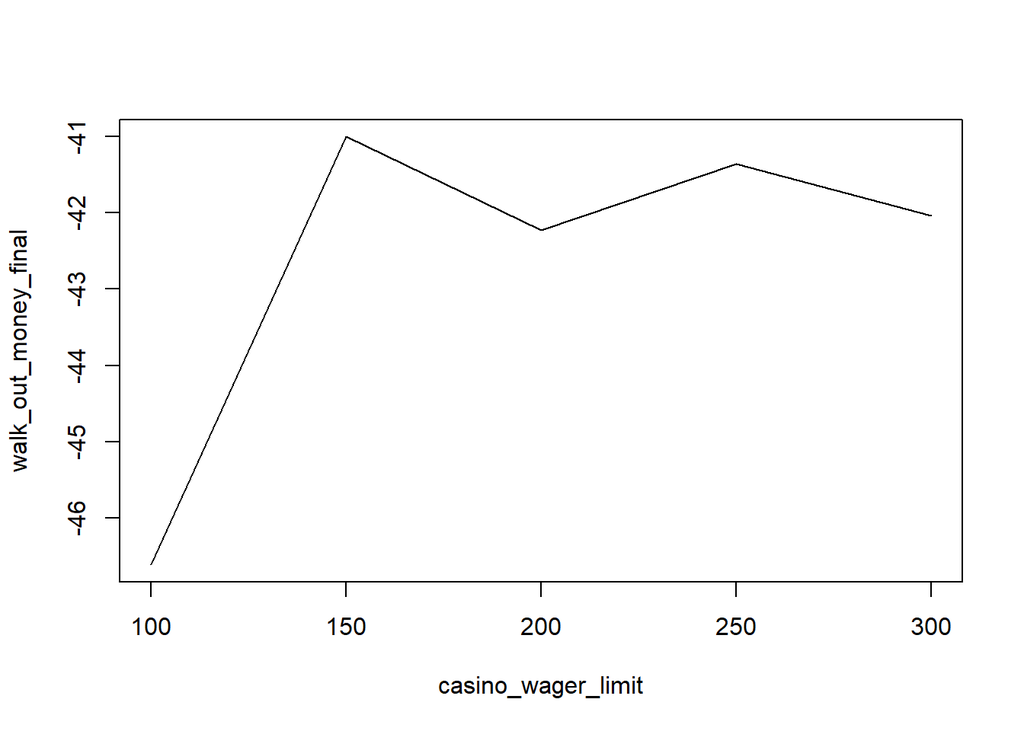

```r
plot(casino_wager_limit,walk_out_money_final,type='l')
```

From the plot, we can know that there is no clear relationship between the casino wager limit and the walk out money final balance.

## 2.5 Average number of plays before stopping

I modified the sample for loop of plays to let the simulation to return the number of of plays of each game. Then I took the average of the simulation result to get the final average number of plays before stopping.

```r
set.seed(10)
#modify the one_series function to return the number of stop play each time when running the simulation
one_series_avg_plays <- function(
    B = 200
  , W = 300
  , L = 1000
  , M = 100
){

  # initial state
  state <- list(
    B = B
  , W = W
  , L = L
  , M = M
  , plays = 0
  , previous_wager = 0
  , previous_win = TRUE
  )

  # vector to store budget over series of plays
  budget <- rep(NA, L)

  # For loop of plays
  for(i in 1:L){
    new_state <- state %>% one_play
    budget[i] <- new_state$B
    if(new_state %>% stop_play){
      return(i)
    }
    state <- new_state
  }
  i
}

# Simulation
walk_out_plays <- rep(NA, 10000)
for(j in seq_along(walk_out_plays)){
  walk_out_plays[j] <- one_series_avg_plays(B = 200, W = 300, L = 1000, M = 100) %>% get_last
}
```

Here is the histogram of the simulation for the average number of plays before stopping

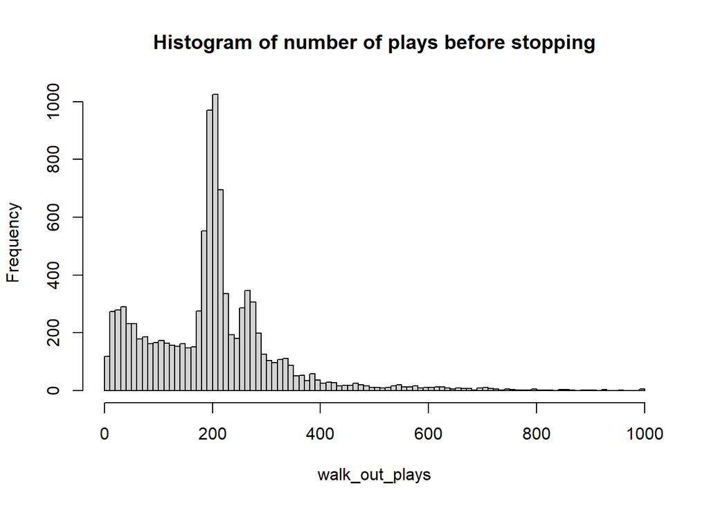

```r
# Walk out play distribution
hist(walk_out_plays, breaks = 100,main='Histogram of number of plays before stopping')
```

```r
# Average number of walk_out_plays
mean(walk_out_plays)
```

```
## [1] 201.8324
```

After taking average of the simulation result, we can know that the average number of plays before stopping for this simulation is 201.

# 3 Results and Conclusions

# 4 Limitations

There are some limitations related to the simulation because the sequence we use does not reach a valid sample size to reach a persuasive result. It also just an indicator of an average expected value instead of the direct indicator of the result. There are also other indicators that could impact the final walk-out money balance.

.